# Investigating the development of Colombia

Links between fertility, mortality, and primary school completion

530574091, 530504135,

University of Sydney | MATH1005 | Thursday 11am Lab

# 1 Executive Summary

# 2 Initial Data Analysis

## 2.1 Source

In this study, Gapminder was used. Gapminder is a website that extensively utilises data sets obtained from the United Nations World Population Prospects (2022) report for its data collection purposes. The United Nations World Population Prospects (2022) is a highly credible organisation that portrays global trends such as population’s distribution of age and sex, as well as mortality rates, fertility rates and international migration. This data collection spans the 1950s to the present, with projections out to 2050.

Additionally, the data for life expectancy was collected from Global Burden of Disease Study, IHME (2017), another highly reliable and credible organisation.

### 2.1.1 Limitations

The extrapolated data provided by The World Population Prospects is not reliable, as global trends in the future may not follow the current worldwide trends. Furthermore, the extrapolated data fails to consider unprecedented events such as natural disasters, economic crises, and other irregularities (United Nations, 2019).As a result, these extrapolation sets were removed from the data set. Furthermore, data collected from developing countries are less reliable, as the lack of civil registration systems can introduce confounding or bias factors that impact the quality of the collected data.  
Key confounding or bias factors include:

1. Marginalised and isolated communities does not have access to registration systems, therefore data from these demographics are not obtained
2. Political instability in developing countries introduces a significant source of potential bias, as data may be subject to manipulation or distortion in favour of politicians or government in power

### 2.1.2 Stakeholders

It is important to note that Gapminder is an independent, non-profitable organisation that receives funding from the government and charities such as the Bill and Melinda Gates Foundation (Supporters | Gapminder, n.d.). As a result, Gapminder does not have any political, religious or economic affiliations. Therefore, the organisation has no financial incentives to manipulate data, making it a reliable source for data collection.

## 2.2 Variables

```r
# Setup code
data <- read.csv("data/Colombia.csv")
library("ggplot2")
library(knitr)


# Structure of the data
str(data)
```

```
## 'data.frame':    52 obs. of  6 variables:
##  $ Year                     : int  1970 1971 1972 1973 1974 1975 1976 1977 1978 1979 ...
##  $ Population               : int  20900000 21400000 21900000 22400000 22900000 23400000 23900000 24400000 25000000 25600000 ...
##  $ Mortality                : num  97.9 94.3 90.6 86.7 82.7 78.5 74.2 69.9 65.7 61.6 ...
##  $ Fertility                : num  5.55 5.3 5.07 4.86 4.68 4.52 4.4 4.28 4.18 4.07 ...
##  $ Life.expectancy          : num  65.9 65.9 65.1 64.9 65.3 66.3 66.8 67.8 68.2 68.5 ...
##  $ Primary.school.completion: num  35.8 53.2 54.1 57.4 58.4 NA NA NA NA NA ...
```

### 2.2.1 Population (integer)

Independent variable Population: This represents the integer value denoting the total population of the country. The initial dataset included prefixes (e.g., ‘k’ for thousand and ‘M’ for million), causing it to be initially categorised as a string variable. However, during the data compilation process, these prefixes were replaced with their respective numerical equivalents.

### 2.2.2 Fertility rate (numeric)

The average fertility rate shows the average number of childbirth per woman for that country. A value of two means the population remains constant.

### 2.2.3 Child mortality (numeric)

The death of children under five years of age per one thousand births.

### 2.2.4 Percentage of girls completing primary school (numeric)

This numerical variable quantifies the enrollment rate in the final grade of primary school by dividing the number of students entering the last grade of primary school by the population of students at that age.

### 2.2.5 Life expectancy at birth (numeric)

The number of years a newborn infant is expected to live at the time of their birth.

# 3 How will maternal fertility affect child mortality?

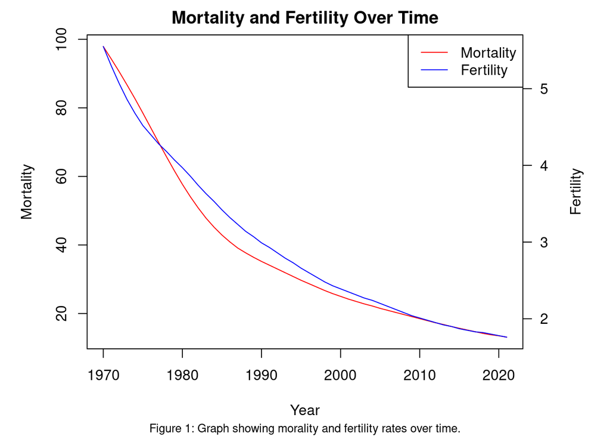

```r
# Set margins for the graph. Otherwise the 'fertility' label doesn't show.
par(mar = c(5, 5, 2, 5))

# Line graph of Morality in red.
plot(data$Year, data$Mortality, col ="red", type ="l", xlab ="Year", ylab ="Mortality")

# Set up a second y-axis on the right hand side of the plot
# Set the parameter 'new' to true to specify a second line
par(new=TRUE)
# Do not include axis ticks or labels (these are on there from the last plot)
plot(data$Year, data$Fertility, col ="blue", type ="l", xaxt ="n", yaxt ="n", xlab ="", ylab ="")

# Add a legend to differentiate between the two lines
legend("topright", legend = c("Mortality", "Fertility"), col=c("red", "blue"), lty = 1)

# Add a y-axis and label for the second line
axis(4, las = 1)
mtext("Fertility", side = 4, line = 2.5)

# Caption and title
title("Mortality and Fertility Over Time")
mtext("Figure 1: Graph showing morality and fertility rates over time.", side = 1, line = 4, cex = 0.8)
```

```r
l <- lm(formula = data$Fertility ~ data$Mortality)


print(l$coefficients)
```

```
##    (Intercept) data$Mortality
##     1.30914393     0.04346595
```

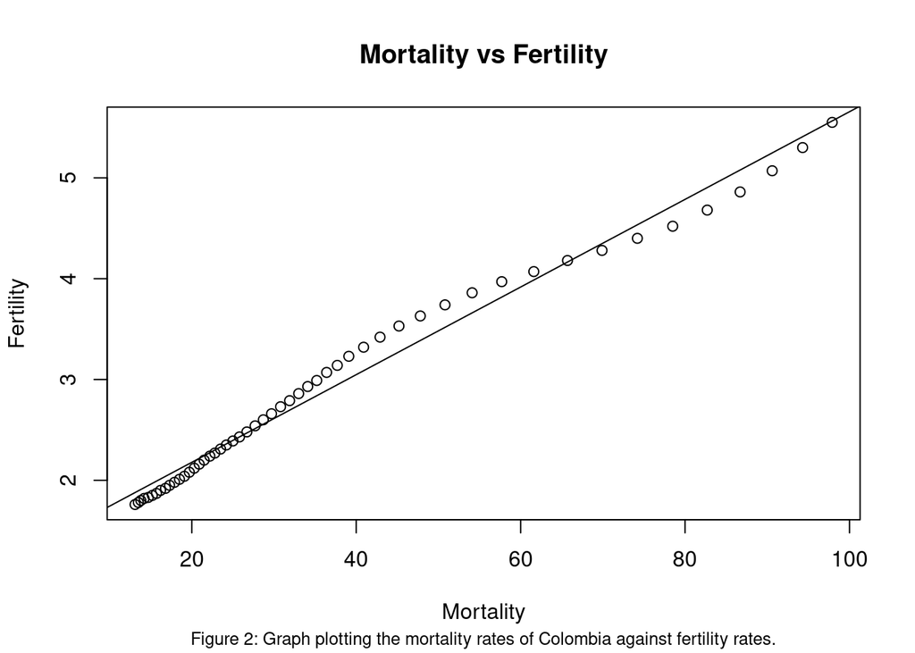

```r
# # Set the plots up side by side
# par(mfrow=c(1,2))


plot(data$Fertility~data$Mortality, xlab = "Mortality", ylab = "Fertility")
abline(l)

# Caption and title
title("Mortality vs Fertility")
mtext("Figure 2: Graph plotting the mortality rates of Colombia against fertility rates.", side=1, line=4, cex=0.8)
```

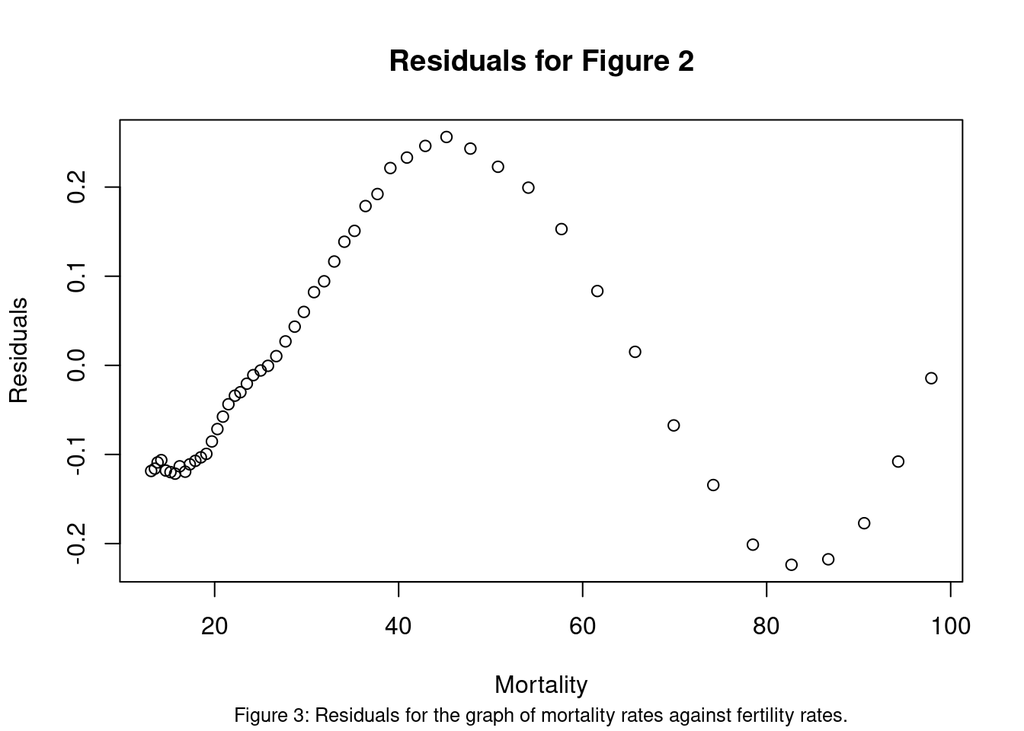

```r
# Axes



plot(data$Mortality, l$residuals, xlab = "Mortality", ylab = "Residuals")
# Caption and title
title("Residuals for Figure 2")
mtext("Figure 3: Residuals for the graph of mortality rates against fertility rates.", side=1, line=4, cex=0.8)
```

```r
r_squared <- round(summary(l)$r.squared, 4)

print(paste("R-squared value: ", r_squared))
```

```
## [1] "R-squared value:  0.9834"
```

Cross-referencing these results with other sources, presents similar ideas of a significant correlation between higher maternal fertility rate and child mortality rate, however data is mostly collected from developing countries such as Ghana, which are more affected by poverty and lack of resources. It can be seen in Table 1 , from the variable LFR (fertility rate) that a 1% increase in fertility rate, will result in a 1.61% increase in infant mortality, thus supporting the data gathered in this report. As seen in Figure 4, the linear regression relating child mortality and fertility shows a moderately strong positive correlation, with a Pearson’s Correlation Coefficient of 0.74. Therefore there is an undisputable correlation between child mortality and maternal fertility, as seen through various sources.

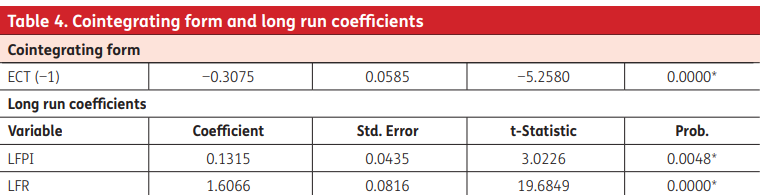

Table 1 : The effect of fertility rate on child mortality rate in Ghana (Asumadu-Sarkodie. S & Owusu .P.A (2016).

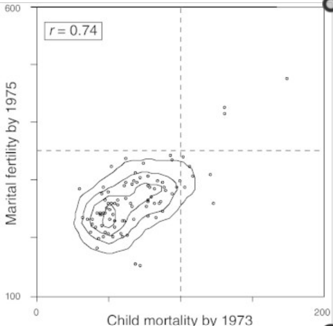

Figure 4 : The relation between child mortality and fertility in Costa Rica (Rosero-Bixby, L., 2005)

However it’s not entirely clear whether or not this is simply correlation or causation in addition to correlation. Pointing to possible causation is the competition and contagion hypothesis, relating to the higher likelihood of infection by disease if being raised among other offspring along with more competition being created for daily necessities such as food and motherly care (Haines, M.R. 1998). This is cited from a reliable source, as it was published within the most recent 25 years and published by The National Academies Press, a highly accredited company. Further evidence for causation suggests that a higher fertility rate can result in maternal depletion, reducing regularity of lactation, thus the only possible food source of the child is unattainable, consequently leading to higher mortality rates (Rosero-Bixby, L., 2005). Thus it can be said there is a strong correlation between child mortality and maternal fertility, along with a possible causation factor as well.

# 4 How does the percentage of girls who complete primary school affect fertility rates?

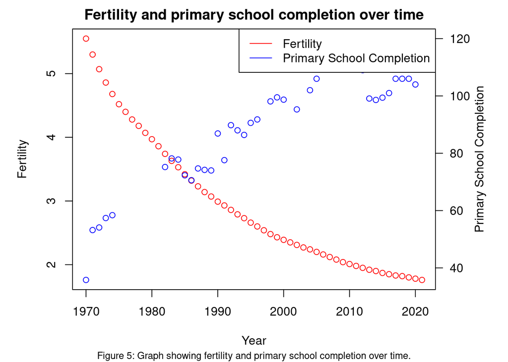

```r
# Set margins for the graph. Otherwise the 'fertility' label doesn't show.
par(mar = c(5, 5, 2, 5))

# Line graph of Fertility in red.
plot(data$Year, data$Fertility, col ="red", xlab ="Year", ylab ="Fertility")

# Set up a second y-axis on the right hand side of the plot
# Set the parameter 'new' to true to specify a second line
par(new=TRUE)
# Do not include axis ticks or labels (these are on there from the last plot)
plot(data$Year, data$Primary.school.completion, col ="blue", xaxt ="n", yaxt ="n", xlab ="", ylab ="")

# Add a legend to differentiate between the two lines
legend("topright", legend = c("Fertility", "Primary School Completion"), col=c("red", "blue"), lty = 1)

# Add a y-axis and label for the second line
axis(4, las = 1)
mtext("Primary School Completion", side = 4, line = 2.5)

# Caption and title
title("Fertility and primary school completion over time")
mtext("Figure 5: Graph showing fertility and primary school completion over time.", side = 1, line = 4, cex = 0.8)
```

```r
# Check for complete cases (rows without missing values)
df <- as.data.frame(data)
complete_rows <- complete.cases(df)

# Create a new data frame with complete cases
data_cleaned <- df[complete_rows, ]

l <- lm(formula = data_cleaned$Fertility ~ data_cleaned$Primary.school.completion)


print(l$coefficients)
```

```
##                            (Intercept) data_cleaned$Primary.school.completion
##                              7.1337681                             -0.0480062
```

[figure not shown]

```r
# # Set the plots up side by side
# par(mfrow=c(1,2))


plot(data_cleaned$Fertility~data_cleaned$Primary.school.completion, xlab = "Fertility", ylab = "Primary School Completion")
abline(l)

# Caption and title
title("Fertility vs Primary School Completion by Girls")
mtext("Figure 6: A graph showing fertility rates against the percentage of girls who completed primary school.", side=1, line=4, cex=0.8)
```

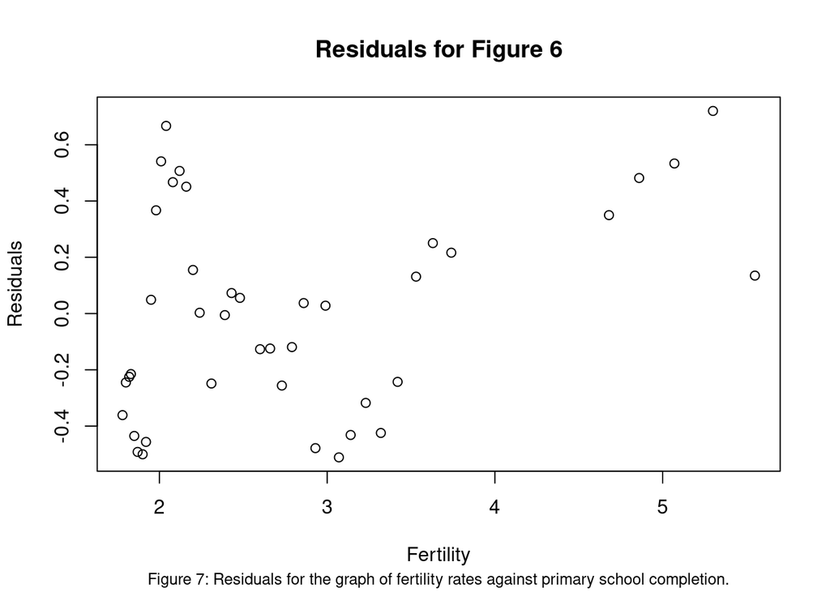

```r
# Axes



plot(data_cleaned$Fertility, l$residuals, xlab = "Fertility", ylab = "Residuals")
# Caption and title
title("Residuals for Figure 6")
mtext("Figure 7: Residuals for the graph of fertility rates against primary school completion.", side=1, line=4, cex=0.8)
```

```r
r_squared <- round(summary(l)$r.squared, 4)

print(paste("R-squared value: ", r_squared))
```

```
## [1] "R-squared value:  0.8766"
```

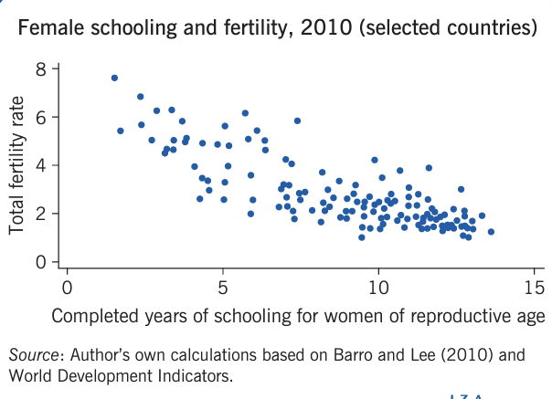

Figure 8

The notion that higher education levels for women negatively affects fertility rate is generally supported by other studies in the field. Ajou university in South Korea performed a similar analysis in February 2016 wherein they compared the average completed years of schooling compared to total fertility rate across multiple countries according to their 2010 consensus (Kim, 2017, pp. 1-3).Their findings can be seen in Figure 8 and align closely with the results found within our linear regression. This is corroborated by the University of Washington’s 2020 study which compares the relationship between fertility rate and the number of women who attained lower secondary education or higher (Eckart, 2020, para 12-14). They found that for almost all developing countries, there was a strong relationship between these two factors (an example graph is provided in Figure 9).

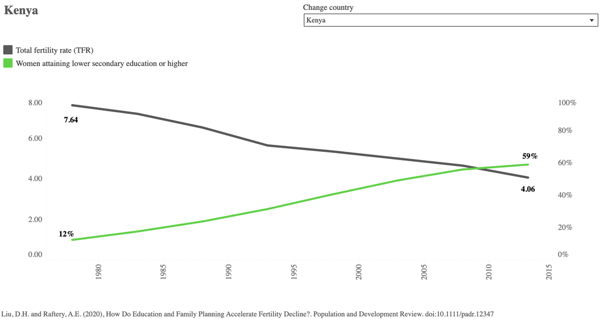

Figure 9

# 5 References

Rosero-Bixby, L (2005) RICA, S. T. I. C. 11 Child Mortality and the Fertility Transition: Aggregated and Multilevel Evidence from Costa Rica.

Haines, M. R. (1998). The relationship between infant and child mortality and fertility: Some historical and contemporary evidence for the United States. From death to birth: Mortality decline and reproductive change, 227-253.

Asumadu-Sarkodie, S., & Owusu, P. A. (2016). The casual nexus between child mortality rate, fertility rate, GDP, household final consumption expenditure, and food production index. Cogent Economics & Finance, 4(1)

Olsen, R. J. (1980). Estimating the effect of child mortality on the number of births. Demography, 17, 429-443.

Pebley, A. R., & Stupp, P. W. (1987). Reproductive patterns and child mortality in Guatemala. Demography, 24(1), 43-60.

Million Death Study Collaborators. (2010). Causes of neonatal and child mortality in India: a nationally representative mortality survey. The Lancet, 376(9755), 1853-1860.

Kim, J. (2016) Female education and its impact on fertility: The relationship is more complex than one may think (1st ed.) Ajou University

Eckart, K. (2020) How birth control, girls’ education can slow population growth (1st ed.) University of Washington

Cornett, A. (2020) Analyzing the Relationship Between Female Education and Fertility Rate (1st ed.) Drake Undergraduate Social Science Journal

Supporters | Gapminder. (n.d.). Gapminder Supporters. Retrieved September 22, 2023, from https://www.gapminder.org/about/about-gapminder/supporters/

United Nations. (2019). World Population Prospects - Population Division - United Nations. Un.org. https://population.un.org/wpp/Methodology/